# Adding dimensions

## Data

Birth weight data, Baystate Medical Center, Springfield, Mass 1986.

See `?MASS::birthwt`

```r
library(tidyverse)
library(ggformula)
library(patchwork)

d <- MASS::birthwt %>%
  mutate(lwt = round(0.453592 * lwt,1),
         race = factor(race, 1:3, c("white", "black", "other")),
         across(c(low, smoke, ht, ui), factor, 0:1, c("no", "yes")))
head(d, 3)
```

```
   low age  lwt  race smoke ptl ht  ui ftv  bwt
85  no  19 82.6 black    no   0 no yes   0 2523
86  no  33 70.3 other    no   0 no  no   3 2551
87  no  20 47.6 white   yes   0 no  no   1 2557
```

## Multivariate graphics

A graphic has only two axes:

- one for the analysis variable (`Y`),
- another for an explanatory variable (`X`)

To add info on other explanatory variables (e.g., potential confounders), use:

- size, color: \(\quad \qquad \qquad \qquad \quad\) for continuous variables
- shape, color, facets: \(\qquad \qquad\) for factors

## Size and color: \(\quad\) continuous variables

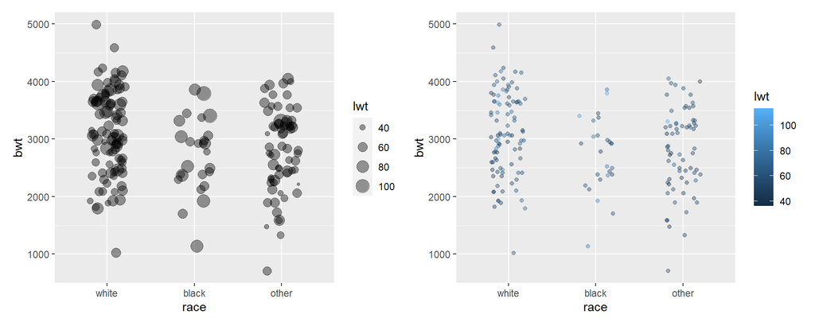

```r
a <- gf_jitter(bwt ~ race, data = d, width = 0.2, alpha = 0.4, size = ~lwt)
b <- gf_jitter(bwt ~ race, data = d, width = 0.2, alpha = 0.4, col = ~lwt)
a + b
```

## Color: \(\quad\) continuous variables and factors

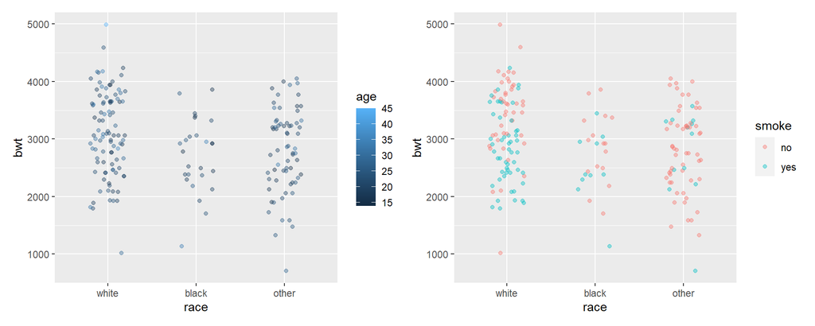

```r
a <- gf_jitter(bwt ~ race, data = d, width = 0.2, alpha = 0.4, col = ~ age)
b <- gf_jitter(bwt ~ race, data = d, width = 0.2, alpha = 0.4, col = ~ smoke)
a + b
```

## Shape vs color: \(\quad\)factors

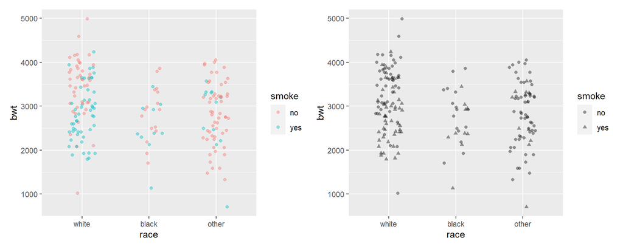

```r
a <- gf_jitter(bwt ~ race, data = d, width = 0.2, alpha = 0.4, col = ~ smoke)
b <- gf_jitter(bwt ~ race, data = d, width = 0.2, alpha = 0.4, shape = ~ smoke)
a + b
```

## Facets: \(\quad\) factors

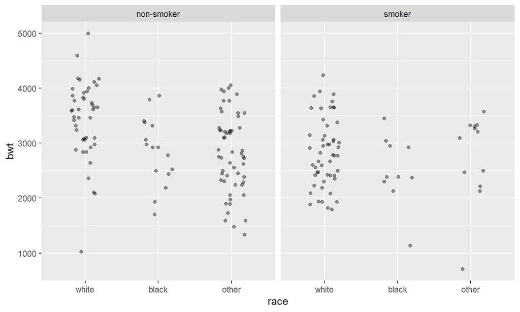

```r
levels(d$smoke) <- c("non-smoker", "smoker")
gf_jitter(bwt ~ race | smoke, data = d, width = 0.2, alpha = 0.4)
```

## Facets: \(\quad\) two factors

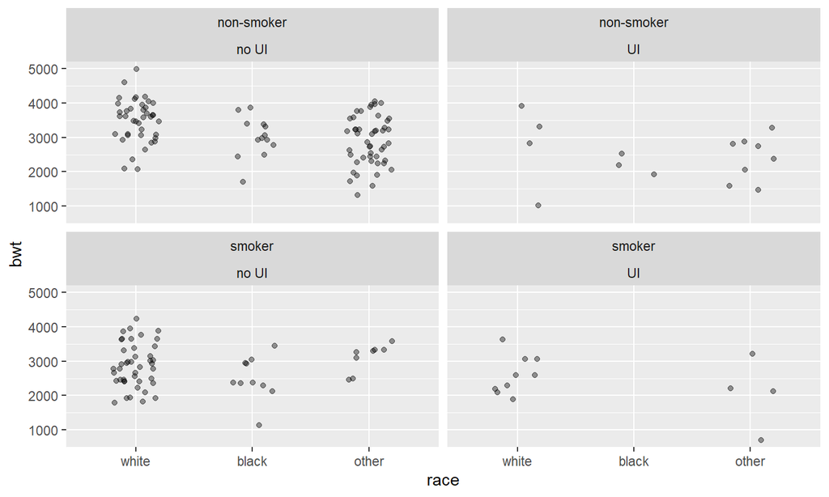

```r
levels(d$ui) <- c("no UI", "UI")
gf_jitter(bwt ~ race | smoke + ui, data = d, width = 0.2, alpha = 0.4)
```

## Five explanatory vars

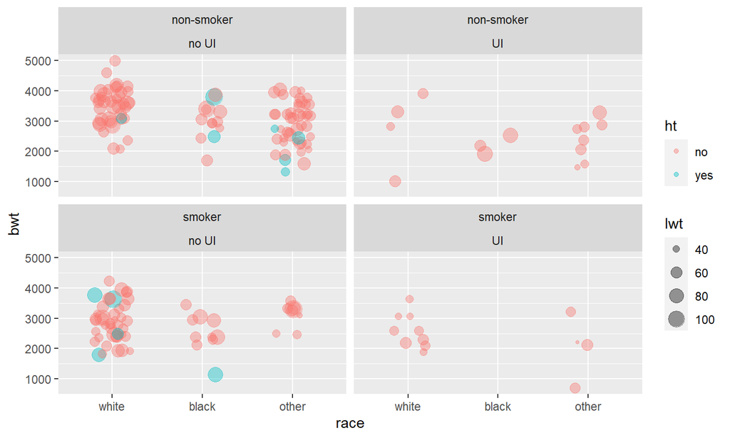

```r
gf_jitter(bwt ~ race | smoke + ui, data = d, width = 0.2, alpha = 0.4, col = ~ ht,
          size = ~ lwt)
```

## Exercise

[PrediMed trial](https://www.nejm.org/doi/10.1056/NEJMoa1800389?url_ver=Z39.88-2003&rfr_id=ori:rid:crossref.org&rfr_dat=cr_pub%3dwww.ncbi.nlm.nih.gov)

Men (55 to 80 years of age) or women (60 to 80 years of age) with no cardiovascular disease at enrollment, who had either type 2 diabetes mellitus or at least three of major risk factors.

1. Install and load package `compareGroups` and then run this:

```r
library(compareGroups)
data(predimed)
levels(predimed$group) <- c("Control", "MD+nuts", "MD+VOO") # for shorter levels
```

1. Produce a jitter plot of `age` by `group` using `alpha = 0.2`):
   - Are all cases within the allowed age range?
   - Is the distribution of age similar in all three groups?
   - Any feature of the age distribution?
2. Repeat adding info on `sex` using `shape` or `color`. Which do you prefer?

(continued in next slide)

## Exercise (cont.)

1. Produce a scatterplot of `waist` and `bmi` faceting by `group` and using color for `sex`:
   - Any difference between groups?
   - Any difference between men and women?
2. Repeat using `gf_density_2d()`
   - Any difference between men and women?